# Random effects, and mixed models

Peter Ralph

22 October – Advanced Biological Statistics

# Example: parent-child heights

## Demonstration: heights

Let’s recreate Galton’s classic analysis: midparent height, adjusted for gender, is a good predictor of child height. *(How good?)*

Link to the data.

```r
galton <- read.table("../Datasets/galton/galton-all.tsv", header=TRUE)
head(galton)
```

```
##   family father mother gender height kids male female
## 1      1   78.5   67.0      M   73.2    4    1      0
## 2      1   78.5   67.0      F   69.2    4    0      1
## 3      1   78.5   67.0      F   69.0    4    0      1
## 4      1   78.5   67.0      F   69.0    4    0      1
## 5      2   75.5   66.5      M   73.5    4    1      0
## 6      2   75.5   66.5      M   72.5    4    1      0
```

## in class

# Random effects

## An example: urchins eat algae

From Logan:

> To investigate density-dependent grazing effects of sea urchin Andrew and Underwood (1993) on filamentous algae measured the percentage of filamentous algae within five quadrats randomly positioned within each of four random patches of reef that were in turn nested within four sea urchin density treatments (no urchins, 33% of natural density, 66% natural density and 100% natural density). The sea urchin density treatment was considered a fixed factor and patch within density treatment as well as the individual quadrats were treated as random factors.

## An example: urchins eat algae

```r
andrew_data <- read.table('../Datasets/Logan_data/andrew.tsv', header=T, sep='\t')
head(andrew_data)
```

```
##   TREAT PATCH QUAD ALGAE
## 1    0%     1    1    46
## 2    0%     1    2    44
## 3    0%     1    3    41
## 4    0%     1    4    29
## 5    0%     1    5    11
## 6    0%     2    1    65
```

There are four variables: `TREAT`, `PATCH`, `QUAD` and `ALGAE`

Main effect factor: `TREAT`

Both `QUAD` and `PATCH` are factors:

```r
andrew_data$QUAD <- factor(andrew_data$QUAD)
andrew_data$PATCH <- factor(andrew_data$PATCH)
andrew_data$TREAT <- factor(andrew_data$TREAT, levels=c("0%", "33%", "66%", "100%"))
```

## Experimental design

```r
with(andrew_data, table(PATCH, QUAD, TREAT))
```

```
## , , TREAT = 0%
##
##      QUAD
## PATCH 1 2 3 4 5
##    1  1 1 1 1 1
##    2  1 1 1 1 1
##    3  1 1 1 1 1
##    4  1 1 1 1 1
##    5  0 0 0 0 0
##    6  0 0 0 0 0
##    7  0 0 0 0 0
##    8  0 0 0 0 0
##    9  0 0 0 0 0
##    10 0 0 0 0 0
##    11 0 0 0 0 0
```

[output cut: 68 more lines]

## Response distribution

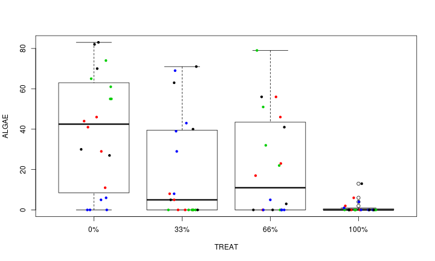

```r
plot(ALGAE ~ TREAT, data=andrew_data)
points(ALGAE ~ jitter(as.numeric(TREAT)), data=andrew_data, pch=20, col=1+as.numeric(PATCH)%%4)
```

Why is this wrong?

```r
summary(lm(ALGAE ~ TREAT, data=andrew_data))
```

```
##
## Call:
## lm(formula = ALGAE ~ TREAT, data = andrew_data)
##
## Residuals:
##    Min     1Q Median     3Q    Max
## -39.20 -19.00  -1.30  12.72  57.45
##
## Coefficients:
##             Estimate Std. Error t value Pr(>|t|)
## (Intercept)   39.200      5.152   7.608 6.17e-11 ***
## TREAT33%     -20.200      7.287  -2.772   0.0070 **
## TREAT66%     -17.650      7.287  -2.422   0.0178 *
## TREAT100%    -37.900      7.287  -5.201 1.62e-06 ***
## ---
## Signif. codes:  0 '***' 0.001 '**' 0.01 '*' 0.05 '.' 0.1 ' ' 1
##
## Residual standard error: 23.04 on 76 degrees of freedom
## Multiple R-squared:  0.2634, Adjusted R-squared:  0.2343
## F-statistic: 9.059 on 3 and 76 DF,  p-value: 3.362e-05
```

What we really want:
$$\text{(algae)} = \text{(mean for treatment)} + \text{(mean offset for patch)} + \text{("noise")} .$$

We *could* do:

```
ALGAE ~ TREAT + PATCH
```

… but do we care about all those patch means?

```r
summary(lm(ALGAE ~ TREAT + PATCH, data=andrew_data))
```

```
##
## Call:
## lm(formula = ALGAE ~ TREAT + PATCH, data = andrew_data)
##
## Residuals:
##    Min     1Q Median     3Q    Max
## -36.80  -2.60  -0.50   4.25  42.20
##
## Coefficients: (3 not defined because of singularities)
##             Estimate Std. Error t value Pr(>|t|)
## (Intercept)   34.200      7.728   4.426 3.82e-05 ***
## TREAT33%       1.600     10.929   0.146  0.88406
## TREAT66%     -14.200     10.929  -1.299  0.19850
## TREAT100%    -31.600     10.929  -2.891  0.00523 **
## PATCH2        27.800     10.929   2.544  0.01339 *
## PATCH3       -32.000     10.929  -2.928  0.00472 **
## PATCH4        24.200     10.929   2.214  0.03038 *
## PATCH5       -33.200     10.929  -3.038  0.00345 **
## PATCH6       -35.800     10.929  -3.276  0.00170 **
## PATCH7         1.800     10.929   0.165  0.86970
## PATCH8            NA         NA      NA       NA
## PATCH9         8.400     10.929   0.769  0.44495
## PATCH10       16.800     10.929   1.537  0.12917
## PATCH11      -19.000     10.929  -1.739  0.08693 .
## PATCH12           NA         NA      NA       NA
## PATCH13       -1.000     10.929  -0.092  0.92738
## PATCH14       -2.600     10.929  -0.238  0.81272
## PATCH15       -1.600     10.929  -0.146  0.88406
## PATCH16           NA         NA      NA       NA
## ---
## Signif. codes:  0 '***' 0.001 '**' 0.01 '*' 0.05 '.' 0.1 ' ' 1
##
## Residual standard error: 17.28 on 64 degrees of freedom
## Multiple R-squared:  0.6512, Adjusted R-squared:  0.5694
## F-statistic: 7.964 on 15 and 64 DF,  p-value: 1.05e-09
```

## Random effects

Small modification:
$$\text{(algae)} = \text{(mean for treatment)} + \text{(random offset for patch)} + \text{("noise")} .$$

We add a *random intercept*:

```
ALGAE ~ TREAT + (1|PATCH)
```

```r
library(lme4)
alglm <- lmer(ALGAE ~ TREAT + (1|PATCH), data=andrew_data)
summary(alglm)
```

```
## Linear mixed model fit by REML ['lmerMod']
## Formula: ALGAE ~ TREAT + (1 | PATCH)
##    Data: andrew_data
##
## REML criterion at convergence: 682.2
##
## Scaled residuals:
##     Min      1Q  Median      3Q     Max
## -1.9808 -0.3106 -0.1093  0.2831  2.5910
##
## Random effects:
##  Groups   Name        Variance Std.Dev.
##  PATCH    (Intercept) 294.3    17.16
##  Residual             298.6    17.28
## Number of obs: 80, groups:  PATCH, 16
##
## Fixed effects:
##             Estimate Std. Error t value
## (Intercept)   39.200      9.408   4.167
## TREAT33%     -20.200     13.305  -1.518
## TREAT66%     -17.650     13.305  -1.327
## TREAT100%    -37.900     13.305  -2.849
##
## Correlation of Fixed Effects:
##           (Intr) TREAT3 TREAT6
## TREAT33%  -0.707
## TREAT66%  -0.707  0.500
## TREAT100% -0.707  0.500  0.500
```

```r
anova(
      lmer(ALGAE ~ TREAT + (1|PATCH), data=andrew_data),
      lm(ALGAE ~ TREAT, data=andrew_data))
```

```
## refitting model(s) with ML (instead of REML)
```

```
## Data: andrew_data
## Models:
## lm(ALGAE ~ TREAT, data = andrew_data): ALGAE ~ TREAT
## lmer(ALGAE ~ TREAT + (1 | PATCH), data = andrew_data): ALGAE ~ TREAT + (1 | PATCH)
##                                                       Df    AIC    BIC
## lm(ALGAE ~ TREAT, data = andrew_data)                  5 734.90 746.81
## lmer(ALGAE ~ TREAT + (1 | PATCH), data = andrew_data)  6 718.83 733.12
##                                                        logLik deviance
## lm(ALGAE ~ TREAT, data = andrew_data)                 -362.45   724.90
## lmer(ALGAE ~ TREAT + (1 | PATCH), data = andrew_data) -353.42   706.83
##                                                        Chisq Chi Df
## lm(ALGAE ~ TREAT, data = andrew_data)
## lmer(ALGAE ~ TREAT + (1 | PATCH), data = andrew_data) 18.069      1
##                                                       Pr(>Chisq)
## lm(ALGAE ~ TREAT, data = andrew_data)
## lmer(ALGAE ~ TREAT + (1 | PATCH), data = andrew_data)   2.13e-05 ***
## ---
## Signif. codes:  0 '***' 0.001 '**' 0.01 '*' 0.05 '.' 0.1 ' ' 1
```

```r
anova(
      lmer(ALGAE ~ TREAT + (1|PATCH), data=andrew_data),
      lmer(ALGAE ~ (1|PATCH), data=andrew_data))
```

```
## refitting model(s) with ML (instead of REML)
```

```
## Data: andrew_data
## Models:
## lmer(ALGAE ~ (1 | PATCH), data = andrew_data): ALGAE ~ (1 | PATCH)
## lmer(ALGAE ~ TREAT + (1 | PATCH), data = andrew_data): ALGAE ~ TREAT + (1 | PATCH)
##                                                       Df    AIC    BIC
## lmer(ALGAE ~ (1 | PATCH), data = andrew_data)          3 721.12 728.27
## lmer(ALGAE ~ TREAT + (1 | PATCH), data = andrew_data)  6 718.83 733.12
##                                                        logLik deviance
## lmer(ALGAE ~ (1 | PATCH), data = andrew_data)         -357.56   715.12
## lmer(ALGAE ~ TREAT + (1 | PATCH), data = andrew_data) -353.42   706.83
##                                                        Chisq Chi Df
## lmer(ALGAE ~ (1 | PATCH), data = andrew_data)
## lmer(ALGAE ~ TREAT + (1 | PATCH), data = andrew_data) 8.2938      3
##                                                       Pr(>Chisq)
## lmer(ALGAE ~ (1 | PATCH), data = andrew_data)
## lmer(ALGAE ~ TREAT + (1 | PATCH), data = andrew_data)    0.04031 *
## ---
## Signif. codes:  0 '***' 0.001 '**' 0.01 '*' 0.05 '.' 0.1 ' ' 1
```

## What *are* the random effects?

```r
ranef(alglm)
```

```
## $PATCH
##    (Intercept)
## 1   -4.1565776
## 2   18.9539940
## 3  -30.7586745
## 4   15.9612581
## 5  -13.6335746
## 6  -15.7949950
## 7   15.4624688
## 8   13.9661009
## 9    5.6945114
## 10  12.6775618
## 11 -17.0835341
## 12  -1.2885391
## 13   0.2493947
## 14  -1.0807102
## 15  -0.2493947
## 16   1.0807102
##
## with conditional variances for "PATCH"
```

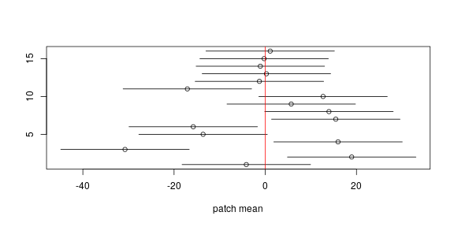

```r
rfs <- ranef(alglm)$PATCH
ses <- rfs[,1] + outer(sqrt(as.vector(attr(rfs, "postVar"))), c(-2, 2), "*")
plot(rfs[,1], 1:nrow(rfs), xlab='patch mean', xlim=range(ses), ylab='')
segments(x0=ses[,1], x1=ses[,2], y0=1:nrow(rfs))
abline(v=0, col='red')
```

# Notes on mixed models

## The math is a lot harder.

For simple linear regression (with *fixed effects*), the *log-likelihood function* is just the sum of the squared residuals.

But with a *mixed model*, the likelihood *averages* over the values of the random effects, which makes everything more difficult.

## You sometimes have to worry about *convergence*.

Since the math is harder, mixed-model-fitting functions like `lmer( )` have to use various sorts of *numerical optimization* methods to find the best-fitting parameters.

Sometimes, these may fail.

Notably, many use the [`REML`](https://en.wikipedia.org/wiki/Restricted_maximum_likelihood) approximation:

```
Usage:

     lmer(formula, data = NULL, REML = TRUE, control = lmerControl(),
          start = NULL, verbose = 0L, subset, weights, na.action,
          offset, contrasts = NULL, devFunOnly = FALSE, ...)
```

## Hypothesis testing?

With fixed effects, for a factor `f`, the comparison

```
anova( lm(y ~ f - 1), lm(y ~ 1) )
```

uses the model that
$$y_i = \beta_{f_i} + \epsilon_i$$
to test against the null hypothesis that
$$H_0 : \beta_1 = \beta_2 = \cdots = \beta_m = 0.$$

With *random* effects,

```
anova( lm(y ~ (1|f) - 1), lm(y ~ 1) )
```

uses the model that
$$\begin{aligned}
y_i &= \beta_{f_i} + \epsilon_i \\
\beta_a &\sim \Normal(0, \eta)
\end{aligned}$$
to test against the null hypothesis that
$$H_0 : \eta = 0.$$

# Back to the height data

## Your turn

1. Add a *random effect* of `family` to the model.
2. How big is the “family” effect?
3. Assess significance by using `anova( )` to compare to a nested model.

Link to the data.

```r
galton <- read.table("../Datasets/galton/galton-all.tsv", header=TRUE)
```

## in class

```r
anova(lmer(height ~ gender + mother + father + (1|family), data=galton),
      lm(height ~ gender + mother + father, data=galton))
```

```
## refitting model(s) with ML (instead of REML)
```

```
## Data: galton
## Models:
## lm(height ~ gender + mother + father, data = galton): height ~ gender + mother + father
## lmer(height ~ gender + mother + father + (1 | family), data = galton): height ~ gender + mother + father + (1 | family)
##                                                                       Df
## lm(height ~ gender + mother + father, data = galton)                   5
## lmer(height ~ gender + mother + father + (1 | family), data = galton)  6
##                                                                          AIC
## lm(height ~ gender + mother + father, data = galton)                  3932.8
## lmer(height ~ gender + mother + father + (1 | family), data = galton) 3891.4
##                                                                          BIC
## lm(height ~ gender + mother + father, data = galton)                  3956.8
## lmer(height ~ gender + mother + father + (1 | family), data = galton) 3920.2
##                                                                        logLik
## lm(height ~ gender + mother + father, data = galton)                  -1961.4
## lmer(height ~ gender + mother + father + (1 | family), data = galton) -1939.7
##                                                                       deviance
## lm(height ~ gender + mother + father, data = galton)                    3922.8
## lmer(height ~ gender + mother + father + (1 | family), data = galton)   3879.4
##                                                                        Chisq
## lm(height ~ gender + mother + father, data = galton)
## lmer(height ~ gender + mother + father + (1 | family), data = galton) 43.401
##                                                                       Chi Df
## lm(height ~ gender + mother + father, data = galton)
## lmer(height ~ gender + mother + father + (1 | family), data = galton)      1
##                                                                       Pr(>Chisq)
## lm(height ~ gender + mother + father, data = galton)
## lmer(height ~ gender + mother + father + (1 | family), data = galton)   4.46e-11
##
## lm(height ~ gender + mother + father, data = galton)
## lmer(height ~ gender + mother + father + (1 | family), data = galton) ***
## ---
## Signif. codes:  0 '***' 0.001 '**' 0.01 '*' 0.05 '.' 0.1 ' ' 1
```

## in class

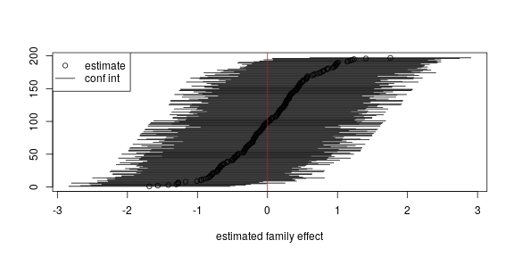

```r
mixed <- lmer(height ~ gender + mother + father + (1|family), data=galton)
rfs <- ranef(mixed)$family
rord <- rank(rfs)
ses <- rfs[,1] + outer(sqrt(as.vector(attr(rfs, "postVar"))), c(-2, 2), "*")
plot(rfs[,1], rord, xlim=range(ses), ylab='',
     xlab='estimated family effect')
segments(x0=ses[,1], x1=ses[,2], y0=rord)
abline(v=0, col='red')
legend("topleft", pch=c(1, NA), lty=c(NA, 1),
       legend=c("estimate", "conf int"))
```

# Multiple comparisons

## A silly example

Suppose 100 people did 100 well-executed experiments to ask if snails move faster while listening to metal than to mozart.

How many would find a statistically significant difference at $p < 0.05$?

Would any find a large effect size?

## A less silly example

Suppose someone conducts a well-controlled study that records the salary and the mean daily consumption of 100 different foods in a bunch of people.

How many of the foods would be statistically significantly correlated with income at $p < 0.05$?

Would any have a large effect size?

## The problem

A $p$-value is

> the probability of seeing something at least as extreme as what was seen in the data, if the null hypothesis were true.

So, if the null hypothesis *is* true, then **by definition**, $p$-values are uniformly distributed between 0 and 1.

## The Bonferroni Correction

A cutoff of $p < 0.05$ ensures you should not wrongly reject the null hypothesis more than 5% of the time.

But, if you do $n$ different tests, all at once?

To tolerate *some* errors, use the *false discovery rate*.

## Example: Bonferroni

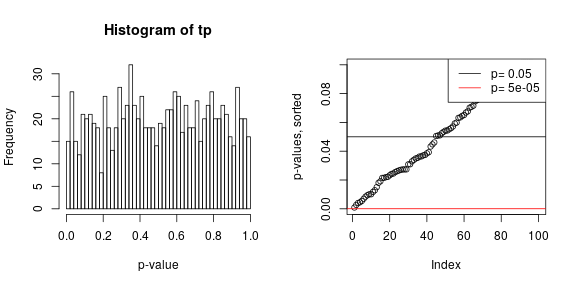

```r
tp <- replicate(1000, t.test(rnorm(20))$p.value)
layout(t(1:2))
hist(tp, breaks=40, xlab='p-value')
plot(sort(tp), xlim=c(1,100), ylim=c(0, 0.1), ylab='p-values, sorted')
abline(h=c(0.05, 0.05/length(tp)), col=1:2)
legend("topright", lty=1, col=1:2, legend=paste("p=", c(0.05, 0.05/length(tp))))
```

## Example: False Discovery Rate

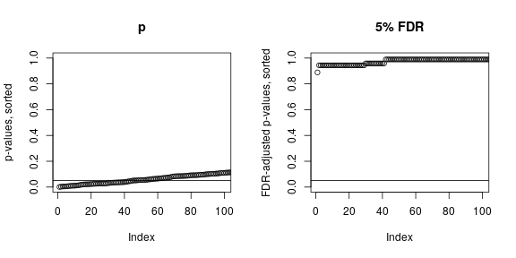

```r
layout(t(1:2))
plot(sort(tp), xlim=c(1,100), ylim=c(0, 1.0), ylab='p-values, sorted', main='p')
abline(h=0.05, col=1:2)
plot(sort(p.adjust(tp, method='fdr')), xlim=c(1,100), ylim=c(0, 1.0), ylab='FDR-adjusted p-values, sorted', main='5% FDR')
abline(h=0.05, col=1:2)
```

# Many regressions

## Gene expression levels

From [*Host Genotype and Microbiota Contribute Asymmetrically to Transcriptional Variation in the Threespine Stickleback Gut* Clayton M. Small, Kathryn Milligan-Myhre, Susan Bassham, Karen Guillemin, William A. Cresko. Genome Biology and Evolution, March 2017.](https://academic.oup.com/gbe/article/9/3/504/3058199)

- Metadata: CVvsGF_RNAseq_Metadata.tsv
- RNA-Seq: CVvsGF_RNAseq_CPM.tsv

## Study design:

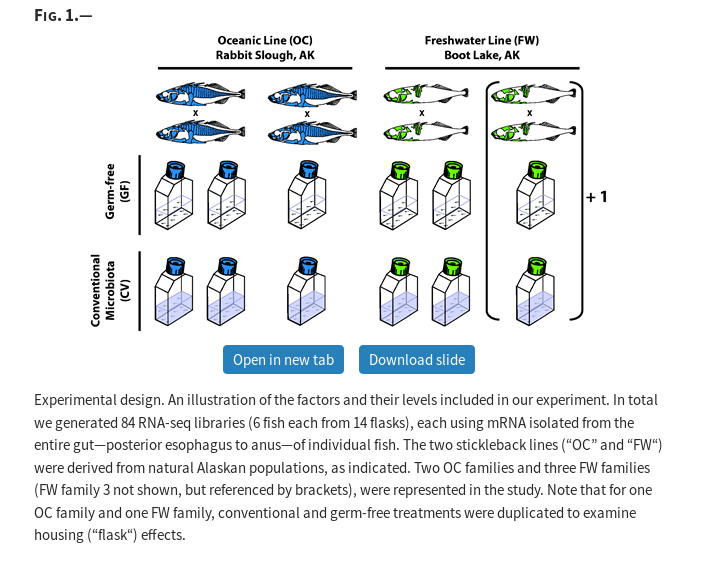

study_design

## The data

```r
fish <- read.table("../Datasets/stickleback_GFvsCV_RNAseq/CVvsGF_RNAseq_Metadata.tsv", header=TRUE, sep='\t')
tmp <- read.table("../Datasets/stickleback_GFvsCV_RNAseq/CVvsGF_RNAseq_CPM.tsv", header=TRUE, sep='\t', stringsAsFactors=FALSE, check.names=FALSE)
genes <- tmp[,1:5]
expression <- as.matrix(tmp[,6:ncol(tmp)])
# sanity check
stopifnot(all(match(colnames(expression), fish$Individual) == 1:nrow(fish)))
```

There are 8506 genes whose expression is measured in 84 fish.

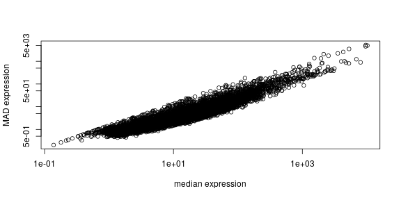

## Normalize

To put coefficients on the same scale:

```r
expr <- sweep(expression, 1, rowMeans(expression), "/")
```

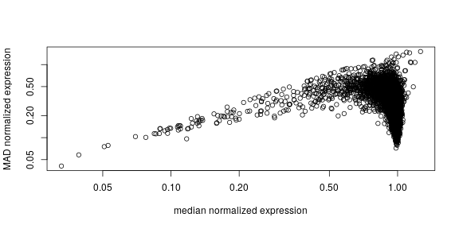

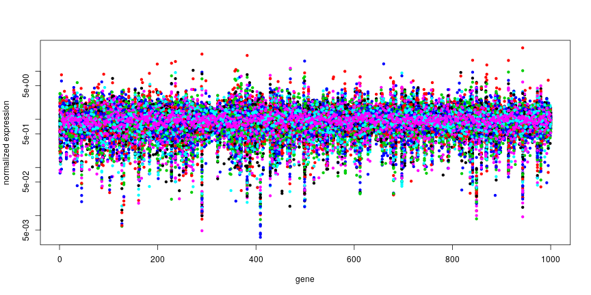

```r
matplot(expr[1:1000,], pch=20, log='y', xlab='gene', ylab='normalized expression')
```

Fit *lots* of models:

```r
pop_lms <- apply(expr, 1, function (x) (lm(x ~ Population, data=fish)))
all_lms <- apply(expr, 1, function (x) (lm(x ~ Population + Treatment + Sex, data=fish)))
anovas <- mapply(anova, pop_lms, all_lms, SIMPLIFY=FALSE)
```

and extract coefficients, $p$-values

```r
pop_coefs <- sapply(pop_lms, coef)
all_coefs <- sapply(all_lms, coef)
pvals <- sapply(lapply(anovas, "[[", "Pr(>F)"), "[", 2)
```

## The $p$-values

… for an ANOVA comparing

```
    gene expression ~ Population
    gene expression ~ Population + Treatment + Sex
```

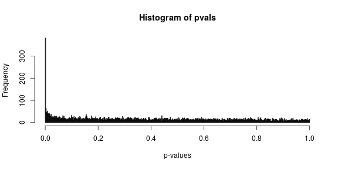

```r
hist(pvals, breaks=500, xlab='p-values')
```

Coefficents, with $p < 0.05$ in red:

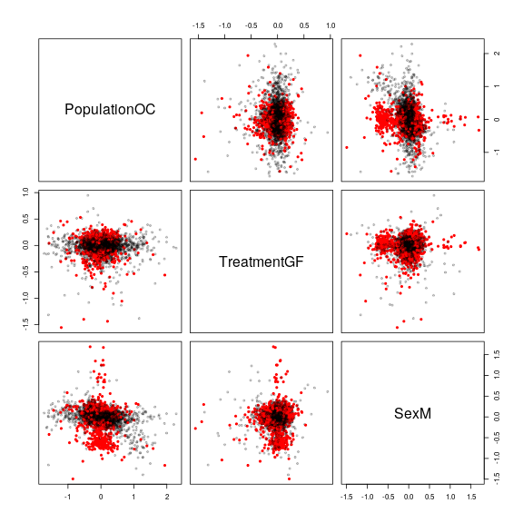

Coefficents, with $p < 0.05/n$ in red:

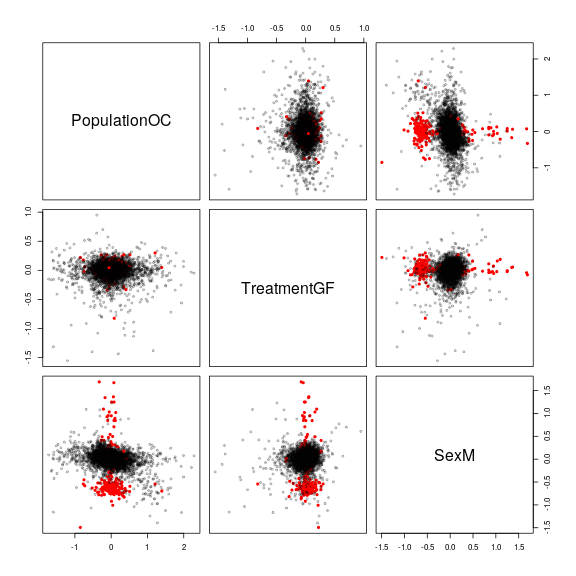

## The Bonferroni Bunch

```r
subset(genes, pvals < 0.05/nrow(genes))
```

```
##                 Gene_ID   Genome_Loc Gene_Start_bp
## 379  ENSGACG00000001729 scaffold_882          1249
## 594  ENSGACG00000002048     groupXXI       2362051
## 833  ENSGACG00000002397       groupV        842100
## 985  ENSGACG00000003874     groupXIX       5074262
## 1005 ENSGACG00000003899     groupXIX       5087963
## 1014 ENSGACG00000003911     groupXIX       5234537
## 1028 ENSGACG00000003928     groupXIX       5268421
## 1042 ENSGACG00000003947     groupXIX       5289965
## 1102 ENSGACG00000004020     groupXIX       5466205
## 1109 ENSGACG00000004028     groupXIX       5497683
## 1128 ENSGACG00000004050     groupXIX       5505366
## 1138 ENSGACG00000004063     groupXIX       5536933
## 1155 ENSGACG00000004088     groupXIX       5663914
## 1161 ENSGACG00000004098     groupXIX       5670651
```

[output cut: 666 more lines]

## The paper

> We limited differential expression analysis to only those genes represented by at least two reads per million mapped (“copies per million,” CPM) in at least 12 of the 84 libraries (see supplementary fig. S1, Supplementary Material online). We normalized read counts for these 15,847 genes using TMM normalization (Robinson and Oshlack 2010) as implemented by the calcNormFactors function of the R/Bioconductor package edgeR (Robinson et al. 2010). In order to perform gene-wise differential expression analyses in a general linear model framework (Law et al. 2014), we supplied the TMM normalization factors to the voom function of the R/Bioconductor package limma (Ritchie et al. 2015), which generated appropriately weighted log2CPM expression values for all observations. We then fit a linear model for each gene including the fixed effects of factor levels for host population, host family (nested within host population), sex, and microbiota treatment using the limma lmFit function. We did not include a library “batch” effect in the model because initial nMDS ordination did not suggest batch as a major source of transcriptional variation, and our stratified assignment of samples to batches controlled for any confounding effect of batch with respect to other factors of interest. To account for variation between replicate flasks we incorporated flask as a random effect in the model using the limma duplicateCorrelation function. Each hypothesis of interest was tested, for each gene, using one or more contrasts via moderated t-tests applied by the limma function eBayes. To evaluate the effect of our microbiota treatment we performed a within-OC contrast, a within-FW contrast, and an overall contrast. Genes expressed differentially in any of these three contrasts were interpreted as being associated with the presence of microbes. We performed a single contrast to test for an overall effect of host population, and a single contrast to test for an interaction between host population and microbiota, both of these accounting for family differences nested within population. Finally, we performed contrasts to test for an effect of sex and a sex-by-microbiota interaction. For each of these seven contrasts, we controlled the false discovery rate (FDR) at 0.1 using the approach of Benjamini and Hochberg (1995), as implemented by the limma topTable function.

# Next week

We’re starting on **Kruschke**, *Doing Bayesian Data Analysis*.